# BreedR Overview

2014-11-08

## BreedR

- R-package implementing **statistical models** specifically suited for forest genetic resources analysts.
- Ultimately [Mixed Models](https://en.wikipedia.org/wiki/Mixed_model), but not necessarily easy to implement and use
- **breedR** acts as an **interface** which provides the means to:
  1. **Combine** any number of these models as **components** of a larger model
  2. Compute automatically **incidence** and **covariance matrices** from a few input parameters
  3. **Fit** the model
  4. Plot data and results, and perform **model diagnostics**

## Functionality

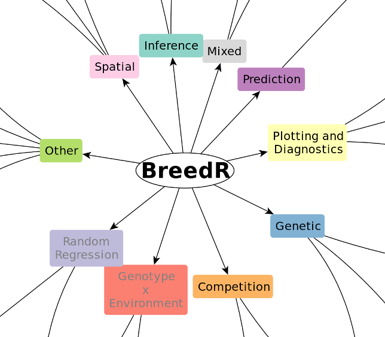

## Inference

## Frequentist

- Currently, only **frequentist inference** is supported via REML estimation of variance components.
- The function `remlf90()`, provides an interface to both `REMLF90` and `AIREMLF90` functions in the [`BLUPF90`](http://nce.ads.uga.edu/wiki/doku.php) suite of Fortran programs.
- Type `?remlf90` for details on the syntax

## Bayesian

- It's on the roadmap for the next year
- Will use a gibbs sampler from [`BLUPF90`](http://nce.ads.uga.edu/wiki/doku.php), and possibly also [`INLA`](http://www.r-inla.org)
- The **interface** will change a bit, separating the model specification from the fit

## Mixed Models

## Simulated dataset

- global intercept of \(5\)
- fixed effect \(x\) with coefficient \(2\)
- random factor \(f_3\) with three independent levels at -1, 0, 1
- residual variance of \(.5\)

```r
n  <- 1e3      # dataset size
mu <- 5        # a global mean
x <- runif(n)  # a covariate
# a factor with 3 levels
f3 <- factor(sample(letters[1:3], n,
                    replace = TRUE))
f3.val <- (-1:1)[f3]
sigma2 <- .5   # residual variance
# linear predictor
eta    <- mu + 2*x + f3.val
# Simulated data
resid <- rnorm(n, sd = sqrt(sigma2))
dat <- data.frame(eta, x, f3,
                  y = eta + resid)
```

| eta | x | f3 | y |
| --- | --- | --- | --- |
| 5.778 | 0.3891 | b | 5.375 |
| 5.747 | 0.3732 | b | 6.301 |
| 6.262 | 0.6309 | b | 6.210 |
| 6.923 | 0.4615 | c | 7.120 |
| 5.077 | 0.5388 | a | 5.435 |
| 5.402 | 0.2008 | b | 5.746 |

We fit the corresponding model \[ \begin{aligned} y = & \mu + \beta x + Z f + \varepsilon \\ f \sim & N(0, \sigma_f^2) \\ \varepsilon \sim & N(0, \sigma_e^2) \end{aligned} \]

to the dataset by using `formula`s for the fixed and random terms.

```r
res <- remlf90(fixed  = y ~ x,
               random = ~ f3,
               data   = dat)
```

```
## Warning: No specification of initial variances.
##      Using default value of 1 for all variance components.
##      See ?breedR.getOption.
```

## Initial variances specification

To avoid the warning, initial values for *all* the variance components must be made explicit using the argument `var.ini`:

```r
res <- remlf90(fixed = y ~ x,
               random = ~ f3,
               var.ini = list(f3 = 2, resid = 10),
               data = dat)
```

Although in most cases the results will not change at all, we encourage to give explicit initial values for variance components. Specially when some estimate can be [artifact](http://nce.ads.uga.edu/wiki/doku.php?id=readme.reml#does_remlf90_always_converge). This is also useful for checking sensitivity to initial values.

## Exploring the results

```r
summary(res)
```

```
## Linear Mixed Model with pedigree and spatial effects fit by AI-REMLF90 ver. 1.110
##    Data: dat
##   AIC     BIC logLik
##  2227 unknown  -1111
##
## Variance components:
##          Estimated variances   S.E.
## f3                      1.00 1.0054
## Residual                0.53 0.0237
##
## Fixed effects:
##           value s.e.
## Intercept  5.03 0.58
## x          1.90 0.08
```

- Note that `AI-REML` has been used by default.
- You can also specify `method = 'em'`.
- Learn about the [difference](https://github.com/famuvie/breedR/wiki/Available-components-and-inference-methods).

## Further *extractor* functions

```r
fixef(res)
```

```
## $Intercept
##   value   s.e.
## 1  5.03 0.5804
##
## $x
##   value    s.e.
## 2 1.898 0.08163
```

```r
ranef(res)
```

```
## $f3
##      value   s.e.
## a -1.00890 0.5794
## b  0.01573 0.5794
## c  0.99317 0.5794
```

## Further *extractor* functions

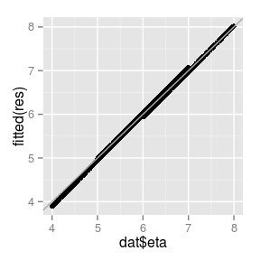

```r
qplot(dat$eta,
      fitted(res)) +
  geom_abline(int = 0,
              sl = 1,
              col = 'darkgrey')
```

```r
str(resid(res))
```

```
##  Named num [1:1000] -0.409 0.547 -0.033 0.221 0.391 ...
##  - attr(*, "names")= chr [1:1000] "1" "2" "3" "4" ...
```

```r
extractAIC(res)
```

```
## [1] 2227
```

```r
logLik(res)
```

```
## 'log Lik.' -1111 (df=unknown)
```

## Additive Genetic Effect

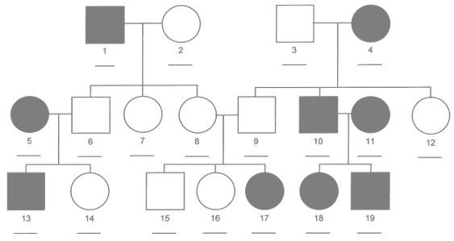

## 1G Metagene dataset

We will use a [`metagene`](http://www.igv.fi.cnr.it/noveltree/) simulated dataset with known additive genetic variance and Breeding Values, for the purpose of demonstration.

```r
data(m1)
summary(m1)
```

```
## Metagene simulated dataset
## ===========================
## Number of individuals:  1760
## Number of traits     :     1
## Number of generations:     1
## Spatial structure    :  Yes
## Selection strategy: (Warning: fixed info)
##       diagonal; 10+10 descendants per mating; select best 80+80
##
## Breeding values: ##########################
## global :
##    Mean    SD   Var Min. 1st Qu. Median 3rd Qu. Max.
## 1 0.972 7.189 51.68  -24      -4      1       6   23
## sex :
##    Mean    SD   Var Min. 1st Qu. Median 3rd Qu. Max.
## f 1.040 7.081 50.14  -24      -4      1       6   20
## m 0.906 7.299 53.28  -21      -4      1       6   23
##
## Phenotypic values: ########################
## global (exc. founders) :
##     Mean    SD   Var Min. 1st Qu. Median 3rd Qu. Max.
## 1 -0.441 10.42 108.6  -40   -7.23 -0.116    6.66 28.7
## sex (exc. founders) :
##     Mean    SD   Var  Min. 1st Qu.  Median 3rd Qu. Max.
## f -0.493 10.66 113.6 -40.0   -7.24 -0.1720    6.88 25.8
## m -0.388 10.19 103.7 -30.1   -7.19 -0.0484    6.35 28.7
##
## Heritability: #############################
## global (exc. founders) :
## [1] 0.4759
## sex (exc. founders) :
##      f      m
## 0.4414 0.5135
```

## Extracting the pedigree

```r
dat <- as.data.frame(m1)  # m1 has lots of info, which usually is not there
ped <- get_pedigree(m1)   # this works only for metagene objects

# this is the usual way to build a pedigree from an observed dataset
# build_pedigree completes the missing information (e.g. founders)
ped <- build_pedigree(c('self', 'dad', 'mum'),
                      data = dat)

check_pedigree(ped)  # performs pedigree sanity checks
```

```
##          full_ped     offsp_follows      codes_sorted codes_consecutive
##              TRUE              TRUE              TRUE              TRUE
```

```r
str(ped)
```

```
## Formal class 'pedigree' [package "pedigreemm"] with 3 slots
##   ..@ sire : int [1:1760] NA NA NA NA NA NA NA NA NA NA ...
##   ..@ dam  : int [1:1760] NA NA NA NA NA NA NA NA NA NA ...
##   ..@ label: chr [1:1760] "1" "2" "3" "4" ...
```

## Fitting an animal model

Fit an animal model with sex as a fixed effect. Note that sex must be a **factor**. Otherwise, it would be interpreted as a regressor.

```r
res.animal <- remlf90(fixed  = phe_X ~ sex,
                      genetic = list(model = 'add_animal',
                                     pedigree = ped,
                                     id = 'self'),
                      data = dat)
```

## Animal model: results

```r
summary(res.animal)
```

```
## Linear Mixed Model with pedigree and spatial effects fit by AI-REMLF90 ver. 1.110
##    Data: dat
##    AIC     BIC logLik
##  11726 unknown  -5861
##
## Variance components:
##          Estimated variances  S.E.
## genetic                 57.4 10.41
## Residual                51.6  6.04
##
## Fixed effects:
##        value s.e.
## sex.f -0.493 0.68
## sex.m -0.388 0.68
```

- Genetic variance a bit overestimated (true simulated variance: ~\(51\))
- This is due to the presence of unaccounted **spatial autocorrelation**

## Extracting Predicted Breeding Values

```
## [1] 0.8066
```

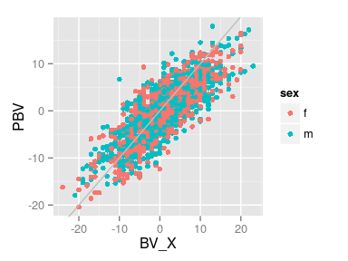

```r
# Predicted Breeding Values
PBV <- res.animal$genetic$fit
# PBV <- ranef(res, 'fit')

# Predicted genetic values vs.
# true Breeding values by sex
qplot(BV_X, PBV,
      color = sex,
      data = dat) +
  geom_abline(int = 0,
              slope = 1,
              col = 'gray')

# Linear correlation between
# true and fitted breeding values
cor(dat$BV_X, PBV)
```

## Exercise

### Handling pedigrees

1. Simulate a worst-case pedigree with the following code, and **check** that it fails all the conditions for a pedigree

   ```r
   set.seed(123); n.ped <- 5
   ped.nightmare <- matrix(sample(100, n.ped*3), n.ped, 3,
                           dimnames = list(NULL, c('self', 'sire', 'dam')))
   ```

2. **Build** a recoded and sorted version of the pedigree
   - what's the size of the recoded pedigree now? Check the conditions
3. Fit an animal model using the following dataset:

   ```r
   test.dat <- data.frame(ped.nightmare, y = rnorm(n.ped))
   ```

   - How many Breeding Values are predicted?
   - Check that `get_pedigree()` matches the one you **built**
   - Get the PBV of the original individuals (use the `map` attribute)

My solution, at the end

## Spatial autocorrelation

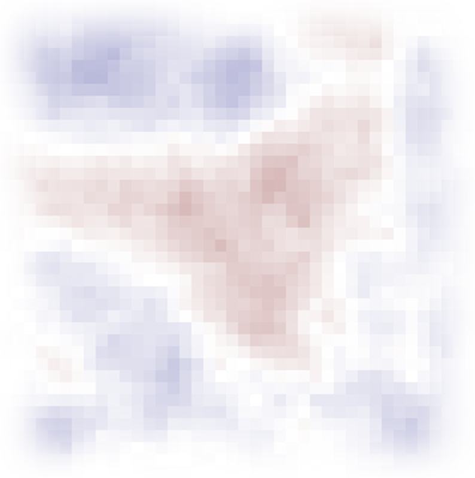

## Diagnosing spatial autocorrelation

- Plot the **variogram of residuals** with `variogram()`
- If the coordinates have not been passed before, they must be provided explicitly.

```r
variogram(res)
```

```
## Error: This breedR object has no spatial structure.
```

```r
variogram(res, coord = dat[, c('irow', 'icol')])
## Or, more generally
coordinates(res) <- dat[, c('irow', 'icol')]
```

## Variograms plot

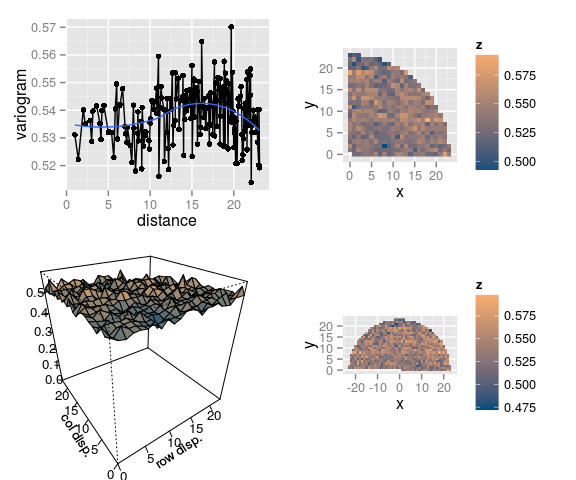

## Interpreting the variograms

- Isotropic variogram: \[ \gamma(h) = \frac12 V[Z(\mathbf{u}) - Z(\mathbf{v})], \quad \text{dist}(\mathbf{u}, \mathbf{v}) = h \]

The **empirical** isotropic variogram is built by aggregating **all the pairs** of points separated by \(h\), **no matter the direction**.

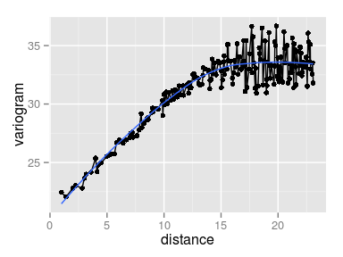

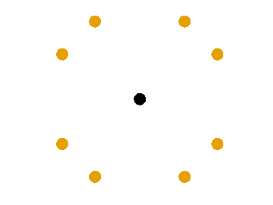

## Interpreting the variograms

- Row/Column variogram: \[ \gamma(x, y) = \frac12 V[Z(\mathbf{u}) - Z(\mathbf{v})], \quad \text{dist}(\mathbf{u}, \mathbf{v}) = (x, y) \]

The **empirical** row/col variogram is built by aggregating **all the pairs** of points separated by exactly \(x\) rows and \(y\) columns.

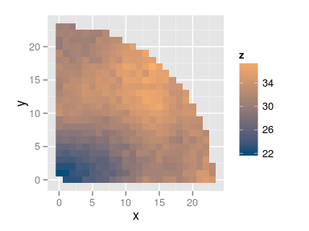

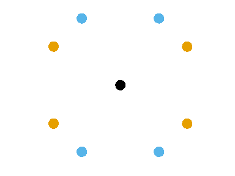

## Interpreting the variograms

- Anisotropic variogram: \[ \gamma(\mathbf{x}) = \frac12 V[Z(\mathbf{u}) - Z(\mathbf{v})], \quad \mathbf{u} = \mathbf{v} \pm \mathbf{x} \]

The **empirical** anisotropic variogram is built by aggregating **all the pairs** of points **in the same direction** separated by \(|\mathbf{x}|\).

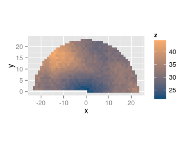

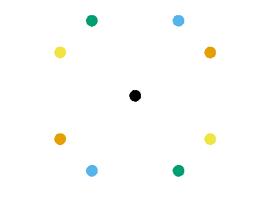

## Accounting for spatial autocorrelation

Include a **spatial effect** in the model

```r
res.ar1 <- remlf90(fixed   = phe_X ~ sex,
                   genetic = list(model = 'add_animal',
                                  pedigree = ped,
                                  id = 'self'),
                   spatial = list(model = 'AR',
                                  coord  = coordinates(m1),
                                  rho    = c(.9, .9)),
                   data    = dat)
```

## Animal-spatial model: results

```r
summary(res.ar1)
```

```
## Linear Mixed Model with pedigree and spatial effects fit by AI-REMLF90 ver. 1.110
##    Data: dat
##    AIC     BIC logLik
##  11310 unknown  -5652
##
## Autoregressive parameters for rows and columns: (0.9, 0.9)
##
## Variance components:
##          Estimated variances S.E.
## genetic                 54.5 9.61
## spatial                 23.9 4.35
## Residual                26.4 5.29
##
## Fixed effects:
##       value s.e.
## sex.f -1.68 1.75
## sex.m -1.36 1.75
```

- Note that the genetic variance is now more accurate

## Variogram of residuals

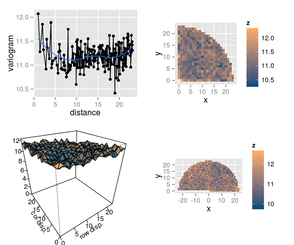

- Spatial autocorrelation removed!

## True vs. predicted spatial effect

- We `plot()` the (true) spatial component of the `metagene` simulated dataset, and the (predicted) spatial component of the model fit. See `?plot.remlf90`
- Furthermore, we keep the same scale by using `compare.plots()`

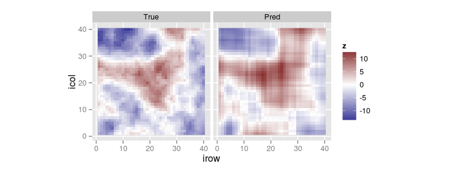

```r
compare.plots(list(True = plot(m1, 'spatial'),
                   Pred = plot(res.ar1, 'spatial')))
```

## Change in Predicted Breeding Values

Animal model only

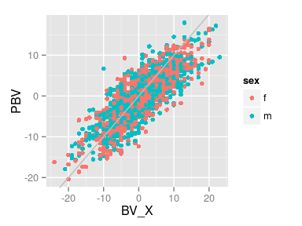

```
## [1] 0.8066
```

Animal/AR model

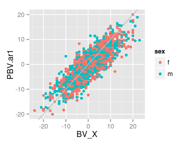

```
## [1] 0.8394
```

## Change in model residuals

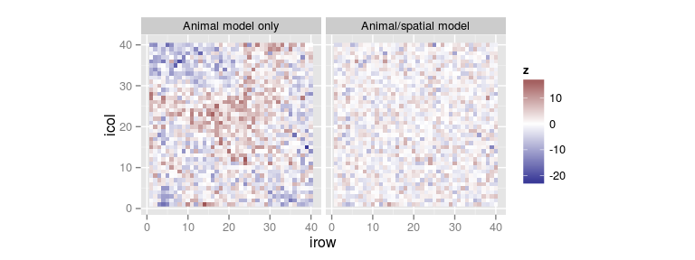

```r
compare.plots(
  list(`Animal model only` = plot(res, 'residuals'),
       `Animal/spatial model` = plot(res.ar1, 'residuals')))
```

## Quantifying residuals' autocorrelation

- You can compute numerical indices of autocorrelation
- See, for example, package `raster`

```r
# Spatial autocorrelation of residuals
tres <- cbind(coordinates(res.ar1), e = residuals(res.ar1))
coordinates(tres) <- c('irow', 'icol')  # cast to SpatialPointsDataFrame
gridded(tres) <- TRUE  # promote to SpatialPixedsDataFrame
tres <- as(tres, "SpatialGridDataFrame")   # SpatialGridDataFrame
tras <- raster(tres)

Geary(tras)  # 1.027 : 1 means no spatial autocorrelation
Moran(tras)  # 0.079 : 0 means no spatial autocorrelation

# Not shown:
# plot(MoranLocal(tras))
# plot(GearyLocal(tras))
```

```
## [1] 1.027
```

```
## [1] 0.07884
```

## Spatial models in **breedR**

- Apply different spatial models to the `globulus` dataset
- The alternative specification of the pedigree runs `build_pedigree()` automatically

```r
str(globulus)
```

```
## 'data.frame':    1021 obs. of  9 variables:
##  $ self : int  69 70 71 72 73 74 75 76 77 78 ...
##  $ dad  : int  0 0 0 0 0 0 0 0 0 4 ...
##  $ mum  : int  64 41 56 55 22 50 67 59 49 8 ...
##  $ gen  : Factor w/ 1 level "1": 1 1 1 1 1 1 1 1 1 1 ...
##  $ gg   : Factor w/ 14 levels "1","2","3","4",..: 14 4 14 14 8 14 14 14 14 11 ...
##  $ bl   : Factor w/ 15 levels "1","2","3","4",..: 13 13 13 13 13 13 13 13 9 9 ...
##  $ phe_X: num  15.76 11.14 19.26 4.78 19.1 ...
##  $ x    : int  0 3 6 9 12 15 18 21 24 27 ...
##  $ y    : int  0 0 0 0 0 0 0 0 0 0 ...
##  - attr(*, "comment")= chr  "Eucalyptus Globulus dataset" "Thanks to Eduardo Cappa and Pablo Pathauer" "Variables:" "self = id of the tree" ...
```

```r
# The genetic component (DRY)
gen.globulus <- list(model    = 'add_animal',
                     pedigree = globulus[, 1:3],
                     id       = 'self')
```

## Blocks model

- Trial **design** with blocks (either complete or not)
- There is a variable identifying the block

```r
res.blk <- remlf90(fixed   = phe_X ~ gg,
                   genetic = gen.globulus,
                   spatial = list(model = 'blocks',
                                  coord = globulus[, c('x','y')],
                                  id    = 'bl'),
                   data    = globulus)
```

- The `blocks` spatial model is **equivalent** to `random = ~ bl`, but:
  - specifying `coord` is convenient for plotting (remember?)
  - `blocks` behaves as expected, even if `bl` is not a **factor**

## B-Splines model

- Use the `em` method! `ai` does not like splines

```r
res.spl  <- remlf90(fixed   = phe_X ~ gg,
                    genetic = gen.globulus,
                    spatial = list(model   = 'splines',
                                   coord   = globulus[, c('x','y')],
                                   n.knots = c(7, 7)),
                    data    = globulus, method  = 'em')
```

- `n.knots` can be **omitted**, and then the number of knots (nok) is determined by the function given in `breedR.getOption('splines.nok')`

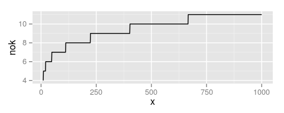

## Autoregressive model

- A separable kronecker product of First order Autoregressive processes on the rows and the colums

```r
res.ar1  <- remlf90(fixed   = phe_X ~ gg,
                    genetic = gen.globulus,
                    spatial = list(model = 'AR',
                                   coord = globulus[, c('x','y')],
                                   rho   = c(.85, .8)),
                    data    = globulus)
```

- `rho` can be **omitted**
- **breedR** runs then all the combinations in the grid produced by the values from `breedR.getOption('ar.eval')`
- **Compare** likelihoods, **refine** the grid search by passing a `data.frame` with custom combinations, and **select** the final parameters

## Comparison of spatial components

|  | blocks | splines | AR1 |
| --- | --- | --- | --- |
| genetic | 4.99 | 4.34 | 5.01 |
| spatial | 2.66 | 3.38 | 4.98 |
| Residual | 10.49 | 10.15 | 7.62 |

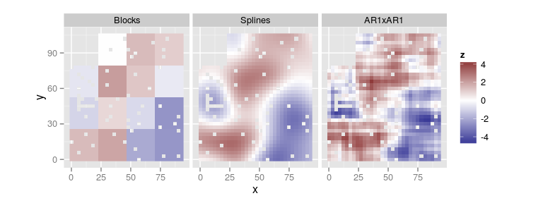

```r
compare.plots(list(Blocks  = plot(res.blk, type = 'spatial'),
                   Splines = plot(res.spl, type = 'spatial'),
                   AR1xAR1 = plot(res.ar1, type = 'spatial')))
```

## Prediction of the spatial effect in unobserved locations

- The type `fullspatial` fills the holes (when possible)
- See `?plot.remlf90`

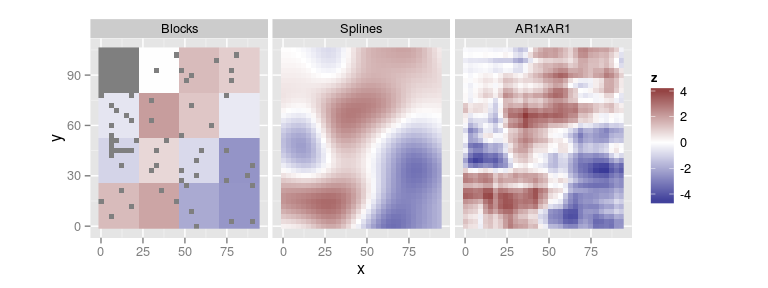

```r
compare.plots(list(Blocks  = plot(res.blk, type = 'fullspatial'),
                   Splines = plot(res.spl, type = 'fullspatial'),
                   AR1xAR1 = plot(res.ar1, type = 'fullspatial')))
```

## Exercise

### Tuning spatial parameters

- Tuning parameters:
  - model `AR`: `rho`
  - model `splines`: `n.knots`
1. Fit the `globulus` dataste with an `AR` model **without specifying** `rho`
2. Visualize the log-likelihood of the fitted models
3. Refine the grid around the most likely values, and refit using `rho = rho.grid`, where

```r
rho.grid <- expand.grid(rho_r = seq(.7, .95, length = 4),
                        rho_c = seq(.7, .95, length = 4))
```

```
- What are now the most likely parameters?
```

My solution, at the end

## Competition

## Theoretical model

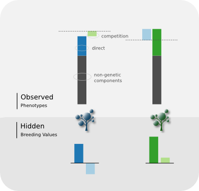

- Each individual have **two** (unknown) Breeding Values (BV)
- The `direct` BV affects its **own** phenotype, while the `competition` BV affects its **neghbours'** (as the King moves)
- The effect of the neighbouring `competition` BVs is given by their sum **weighted by** \(1/d^\alpha\), where \(\alpha\) is a tuning parameter called `decay`
- Each set of BVs is modelled as a zero-mean **random effect** with structure matrix given by the **pedigree** and independent **variances** \(\sigma^2_a\) and \(\sigma^2_c\)
- Both random effects are modelled jointly with **correlation** \(\rho\)

## Permanent Environmental Effect (pec)

- **Optional** effect with **environmental** (rather than genetic) basis
- Modelled as an individual **independent** random effect that affects **neighbouring** trees in the same (weighted) way

## Simulation of data

**breedR** implements a convenient dataset **simulator** which keeps a similar syntax.

- See `?simulation` for details on the syntax

```r
# Simulation parameters
grid.size <- c(x=20, y=25) # cols/rows
coord <- expand.grid(sapply(grid.size,
                            seq))
Nobs <- prod(grid.size)
Nparents <- c(mum = 20, dad = 20)
sigma2_a <- 2   # direct add-gen var
sigma2_c <- 1   # compet add-gen var
rho      <- -.7 # gen corr dire-comp
sigma2_s <- 1   # spatial variance
sigma2_p <- .5  # pec variance
sigma2   <- .5  # residual variance

S <- matrix(c(sigma2_a,
              rho*sqrt(sigma2_a*sigma2_c),
              rho*sqrt(sigma2_a*sigma2_c),
              sigma2_c),
            2, 2)

set.seed(12345)
simdat <-
  breedR.sample.phenotype(
    fixed   = c(beta = 10),
    genetic = list(model = 'competition',
                   Nparents = Nparents,
                   sigma2_a = S,
                   check.factorial=FALSE,
                   pec = sigma2_p),
    spatial = list(model = 'AR',
                   grid.size = grid.size,
                   rho   = c(.3, .8),
                   sigma2_s = sigma2_s),
    residual.variance = sigma2
    )

## Remove founders
dat <- subset(simdat,
              !(is.na(simdat$sire)
                & is.na(simdat$dam)))
```

## Fitting a competition model

```r
system.time(
  res.comp <- remlf90(fixed   = phenotype ~ 1,
                      genetic = list(model = 'competition',
                                     pedigree = dat[, 1:3],
                                     id = 'self',
                                     coord = dat[, c('x', 'y')],
                                     competition_decay = 1,
                                     pec = list(present = TRUE)),
                      spatial = list(model = 'AR',
                                     coord = dat[, c('x', 'y')],
                                     rho   = c(.3, .8)),
                      data = dat,
                      method = 'em')  # AI diverges
  )
```

```
##    user  system elapsed
##  140.28    0.24  141.86
```

## True vs. estimated parameters

|  | True | Estimated |
| --- | --- | --- |
| direct | 2.0 | 2.50 |
| compet. | 1.0 | 1.03 |
| correl. | -0.7 | -0.76 |
| spatial | 1.0 | 1.24 |
| pec | 0.5 | 0.20 |
| residual | 0.5 | 0.17 |

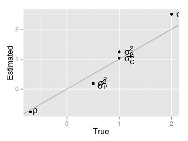

## Exercise

### Competition models

1. Plot the true vs predicted:
   - direct and competition Breeding Values
   - spatial effects
   - pec effects
2. Plot the residuals and their variogram
   - Do you think the residuals are independent?
   - How would you improve the analysis?

My solution, at the end

## Prediction

## Predicting values for unobserved trees

- You can predict the Breeding Value of an **unmeasured tree**
- Or the expected phenotype of a death tree (or an hypothetical scenario)
- Information is gathered from the covariates, the spatial structure and the pedigree
- Simply **include the individual** in the dataset with the response set as `NA`

## Leave-one-out cross-validation

- Re-fit the simulated competition data with one measurement removed
- Afterwards, compare the predicted values for the **unmeasured** individuals with their true simulated values

```r
rm.idx <- 8
rm.exp <- with(dat[rm.idx, ],
               phenotype - resid)
dat.loo <- dat
dat.loo[rm.idx, 'phenotype'] <- NA
```

|  | True | Pred.loo |
| --- | --- | --- |
| direct BV | -1.48 | 0.11 |
| competition BV | 0.46 | 0.36 |
| exp. phenotype | 6.80 | 9.88 |

## Exercise

### Cross validation

1. Extend the last table to include the predicted value when the phenotype is measured
2. Remove 1/10th of the phenotypes randomly, and predict their expected phenotype
   - Have the parameter estimations changed too much?
3. Compute the Root Mean Square Error (RMSE) of Prediction with respect to the true values

My solution, at the end

## Some more features

## Metagene interface

- We have used simulated data from the [`metagene`](http://www.igv.fi.cnr.it/noveltree/) software
- If you simulate data, import the results with `read.metagene()`
- Use several common methods with a `metagene` object:
  - `summary()`, `plot()`, `as.data.frame()`
- Plus some more specific `metagene` functions:
  - `b.values()`, `get.ntraits()`, `ngenerations()`, `nindividuals()`, `get.pedigree()`
- And specific functions about spatial arrangement:
  - `coordinates()` extract coordinates
  - `sim.spatial()` simulates some spatial autocorrelation

## Simulation framework

- The function `breedR.sample.phenotype()` simulates datasets from all the model structures available in **breedR**
- Limitation: only one generation, with random matings of founders
- See `?simulation` for details

## Remote computation

**If** you have access to a **Linux** server through **SSH**, you can perform computations remotely

- Take advantage of more **memory** or **faster** processors
- **Parallelize** jobs
- Free **local resources** while fitting models
- See `?remote` for details

## Package options

- **breedR** features a list of configurable options
- Use `breedR.setOption(...)` for changing an option during the current sesion
- Set options permanently in the file `$HOME/.breedRrc`
- see `?breedR.option` for details

```r
breedR.getOption()
```

```
## $ar.eval
## [1] -0.8 -0.2  0.2  0.8
##
## $breedR.bin
## [1] "/home/facu/lib/R/library/breedR/bin/linux"
##
## $splines.nok
## determine.n.knots
##
## $default.initial.variance
## [1] 1
##
## $col.seq
## [1] "#034E7B" "#FDAE6B"
##
## $col.div
## [1] "#3A3A98FF" "#832424FF"
##
## $cygwin
## [1] "C:/cygwin"
##
## $cygwin.home
## [1] "/home/facu"
##
## $ssh.auth.sock
## [1] "/tmp/ssh-auth-sock-facu"
##
## $remote.host
## [1] "147.99.222.196"
##
## $remote.user
## [1] "fmunoz"
##
## $remote.port
## [1] 22
##
## $remote.bin
## [1] "/home/fmunoz/R/x86_64-unknown-linux-gnu-library/3.0/breedR/bin/linux"
##
## $ssh.options
## [1] "-x -o BatchMode=yes -o TCPKeepAlive=yes -e none"
```

## Roadmap

## Future developments

- Bayesian inference
- Multi-trait support
- Genotype\(\times\)Environment interaction
- Support for longitudinal data

## Final remarks

## Where to find help

- Package's help: `help(package = breedR)`
  - Help pages
  - Code demos `demo(topic, package = 'breedR')` (omit `topic` for a list)
  - Vignettes (none yet)
- [Wiki pages](https://github.com/famuvie/breedR/wiki)
  - Guides, tutorials, FAQ
- Mailing list http://groups.google.com/group/breedr
  - Questions and debates about usage and interface
- [Issues page](https://github.com/famuvie/breedR/issues)
  - Bug reports
  - Feature requests

## License

- **BreedR** is FOSS. Licensed [GPL-3](http://www.gnu.org/licenses/gpl-3.0.html)
  - `RShowDoc('LICENSE', package = 'breedR')`
- You can **use** and **distribute** breedR for any purpose
- You can **modify** it to suit your needs
  - we encourage to!
  - please consider contributing your improvements
  - you can **distribute** your modified version under the GPL
- However, **breedR** makes (intensive) use of the [`BLUPF90`](http://nce.ads.uga.edu/wiki/doku.php) suite of Fortran programs, which **are not free**

## (My) solutions to exercises

## Handling pedigrees #1

### Checking pedigree properties

| self | sire | dam |
| --- | --- | --- |
| 29 | 5 | 87 |
| 79 | 50 | 98 |
| 41 | 83 | 60 |
| 86 | 51 | 94 |
| 91 | 42 | 9 |

```r
check_pedigree(ped.nightmare)
```

```
##          full_ped     offsp_follows      codes_sorted codes_consecutive
##             FALSE             FALSE             FALSE             FALSE
```

## Handling pedigrees #2

### Recoding a pedigree

```r
ped.fix <- build_pedigree(1:3, data = ped.nightmare)
check_pedigree(ped.fix)
```

```
##          full_ped     offsp_follows      codes_sorted codes_consecutive
##              TRUE              TRUE              TRUE              TRUE
```

| self | sire | dam |
| --- | --- | --- |
| 1 | NA | NA |
| 2 | NA | NA |
| 3 | NA | NA |
| 4 | 1 | 3 |
| 5 | NA | NA |
| 6 | NA | NA |
| 7 | 5 | 6 |
| 8 | NA | NA |
| 9 | NA | NA |
| 10 | NA | NA |
| 11 | NA | NA |
| 12 | 9 | 11 |
| 13 | NA | NA |
| 14 | 10 | 13 |
| 15 | 8 | 2 |

## Handling pedigrees #3

### Fitting a model with a recoded pedigree

```r
res.raw <- remlf90(fixed   = y ~ 1,
                   genetic = list(model = 'add_animal',
                                  pedigree = ped.nightmare,
                                # pedigree = test.dat[, 1:3],  # same thing
                                  var.ini = 1,
                                  id = 'self'),
                   var.ini = list(resid = 1),
                   data    = test.dat)
## pedigree has been recoded!
nrow(ranef(res.raw)$genetic)

## The pedigree used in the model matches the one manually built
identical(ped.fix, get_pedigree(test.res))
```

```
## [1] 15
```

```
## [1] TRUE
```

## Handling pedigrees #3-3

### Recovering BVs

```r
## PBVs of the observed individuals
# original -> final codes
map <- attr(get_pedigree(res.raw), 'map')
recoded.self <- map[test.dat$self]
PBVs <- ranef(res.raw)$genetic[recoded.self, ]
rownames(PBVs) <- test.dat$self
kable(PBVs)
```

|  | value | s.e. |
| --- | --- | --- |
| 29 | 0.2127 | 0.8861 |
| 79 | -1.2912 | 0.8861 |
| 41 | 0.4175 | 0.8861 |
| 86 | -0.1757 | 0.8861 |
| 91 | 0.8366 | 0.8861 |

```r
## Note: this is planned to be
## automatically obtained with
## ranef(res.raw, type = 'fit')
```

## Spatial #1

### Grid search of autocorrelation parameters

```r
res.ar  <- remlf90(fixed  = phe_X ~ gg,
                   genetic = list(model = 'add_animal',
                                  pedigree = globulus[,1:3],
                                  id = 'self'),
                   spatial = list(model = 'AR',
                                  coord = globulus[, c('x','y')]),
                   data = globulus)
```

## Spatial #2

### Visualize log-likelihoods

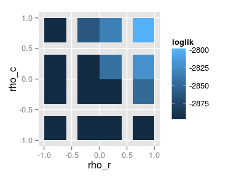

| rho_r | rho_c | loglik |
| --- | --- | --- |
| -0.8 | -0.8 | -2898 |
| -0.2 | -0.8 | -2898 |
| 0.2 | -0.8 | -2898 |
| 0.8 | -0.8 | -2898 |
| -0.8 | -0.2 | -2898 |
| -0.2 | -0.2 | -2898 |
| 0.2 | -0.2 | -2897 |
| 0.8 | -0.2 | -2848 |
| -0.8 | 0.2 | -2898 |
| -0.2 | 0.2 | -2898 |
| 0.2 | 0.2 | -2843 |
| 0.8 | 0.2 | -2821 |
| -0.8 | 0.8 | -2898 |
| -0.2 | 0.8 | -2863 |
| 0.2 | 0.8 | -2833 |
| 0.8 | 0.8 | -2800 |

```r
qplot(rho_r, rho_c,
      fill = loglik,
      geom = 'tile',
      data = res.ar$rho)
```

## Spatial #3

### Refine grid

```r
res.ar  <- remlf90(fixed  = phe_X ~ gg,
                   genetic = list(model = 'add_animal',
                                  pedigree = globulus[,1:3],
                                  id = 'self'),
                   spatial = list(model = 'AR',
                                  coord = globulus[, c('x','y')],
                                  rho = rho.grid),
                   data = globulus)
summary(res.ar)
```

```
## Linear Mixed Model with pedigree and spatial effects fit by AI-REMLF90 ver. 1.110
##    Data: data
##   AIC     BIC logLik
##  5603 unknown  -2798
##
## Autoregressive parameters for rows and columns: (0.866666666666667, 0.783333333333333)
##
## Variance components:
##          Estimated variances S.E.
## genetic                 5.09 1.71
## spatial                 4.98 1.05
## Residual                7.58 1.50
##
## Fixed effects:
##       value s.e.
## gg.1  13.35 0.72
## gg.2  14.33 0.91
## gg.3  15.94 0.77
## gg.4  11.59 0.94
## gg.5  15.91 0.82
## gg.6   9.59 1.70
## gg.7  13.76 1.57
## gg.8  15.52 0.75
## gg.9  16.30 0.83
## gg.10 12.68 1.15
## gg.11 16.46 0.98
## gg.12 16.80 1.14
## gg.13 15.78 1.57
## gg.14 14.21 0.65
```

## Competition #1

### True vs. predicted components

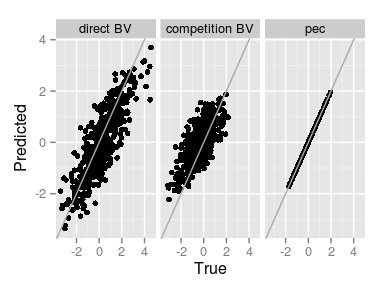

```r
comp.pred <-
  rbind(
    data.frame(
      Component = 'direct BV',
      True = dat$BV1,
      Predicted = res.comp$genetic$fit$direct),
    data.frame(
      Component = 'competition BV',
      True = dat$BV2,
      Predicted = res.comp$genetic$fit$competition),
    data.frame(
      Component = 'pec',
      True      = dat$pec,
      Predicted = dat$pec))  # BUG: Where is it??

ggplot(comp.pred,
       aes(True, Predicted)) +
  geom_point() +
  geom_abline(int = 0, sl = 1,
              col = 'darkgray') +
  facet_grid(~ Component)
```

## Competition #2

### Map of residuals and their variogram

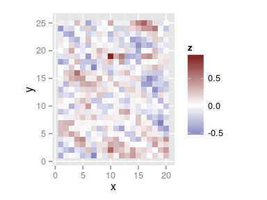

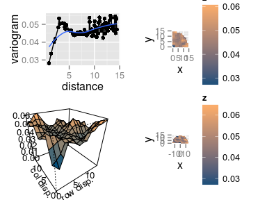

```r
plot(res.comp, type = 'resid')
variogram(res.comp)
```

## Cross-validation #1

### Include prediction with full data

```r
valid.pred$Pred.full <-
  c(c(sapply(res.comp$genetic$fit,
             function(x) x[rm.idx]),
      fitted(res.comp)[rm.idx]))

kable(round(valid.pred[,c(1,3,2)],
            2))
```

|  | True | Pred.full | Pred.loo |
| --- | --- | --- | --- |
| direct BV | -1.48 | -1.30 | 0.11 |
| competition BV | 0.46 | 0.99 | 0.36 |
| exp. phenotype | 6.80 | 7.39 | 9.88 |

## Cross-validation #2

### Perform cross-validation on 1/10th of the observations

```r
rm.idx <- sample(nrow(dat),
                 nrow(dat)/10)
dat.cv <- dat
dat.cv[rm.idx, 'phenotype'] <- NA
## Re-fit the model and build table
```

|  | Fully.estimated | CV.estimated |
| --- | --- | --- |
| direct | 2.50 | 2.70 |
| compet. | 1.03 | 0.87 |
| correl. | -0.76 | -0.80 |
| spatial | 1.24 | 1.03 |
| pec | 0.20 | 0.51 |
| residual | 0.17 | 0.13 |

## Cross-validation #3

### MSE of Prediction

```r
true.exp.cv <- with(dat[rm.idx, ], phenotype - resid)
sqrt(mean((fitted(res.comp.cv)[rm.idx] - true.exp.cv)^2))
```

```
## [1] 1.498
```